# [Art]20200426_cnn_single_sample_test

In this post, we will walk through the process of creating a deep segmentation model using a pytorch library SMP (Segmentation Models Pytorch). To verify that the modeling pipeline is working and the parameters are set up properly (as an initial experiment), we will also train the model using a small subset of the cloud satellite data in the Kaggle competition "Understanding the Cloud".

Highlights:

- A quick deployment of a Fully Convolutional Neural Network (FCNN) using SMP.
- Using real satellite imagery on cloud formation as training data.
- A verification of the model set-up by training on a small subset of data.

First, let's import the necessary libraries and set up the environment.

```python
import tensorflow as tf
tf.test.gpu_device_name()
```

```
''
```

```python
from google.colab import drive

drive.mount('/content/drive', force_remount=True)
```

```
Go to this URL in a browser: https://accounts.google.com/o/oauth2/auth?client_id=947318989803-6bn6qk8qdgf4n4g3pfee6491hc0brc4i.apps.googleusercontent.com&redirect_uri=urn%3aietf%3awg%3aoauth%3a2.0%3aoob&response_type=code&scope=email%20https%3a%2f%2fwww.googleapis.com%2fauth%2fdocs.test%20https%3a%2…

Enter your authorization code:
··········
```

```python
PATH = '/content/drive/My Drive/kaggle_cloud/data'
%cd /content/drive/My\ Drive/kaggle_cloud/src_cloudflower2/CloudFlower2

# If we need to check out the latest code, uncomment below:
!git pull
```

```
/content/drive/My Drive/kaggle_cloud/src_cloudflower2/CloudFlower2
Already up to date.
```

```python
# The necessary libraries and the version numbers are specified in the requirement.txt
!pip install -r requirements.txt
```

[output not shown]

```python
import cv2
import matplotlib.pyplot as plt
import albumentations as albu
from albumentations import torch as AT

import numpy as np
import pandas as pd

import torch
from torch.utils.data import TensorDataset, DataLoader, Dataset
from torch import nn
```

```python
################################################################
# Set a seed for the random number generator (so the results can be reproduced)
################################################################
torch.manual_seed(0)
np.random.seed(0)
```

# 1. Load Data

In this part, we will loan and take a quick view of the cloud image dataset. To demonstrate the neural network has a correct definition of its architecture and the optimization algorithm is working properly, **we will only use fifty images for training and validation.**

```python
from utils.dataset_helper import read_train_df, split_image_dataset

PATH = '/content/drive/My Drive/kaggle_cloud/data'

csvfile = f'{PATH}/train.csv'
data_df = read_train_df(csvfile)
print(data_df.shape)
data_df.head()
```

```
(22184, 4)
```

|  | Image_Label | EncodedPixels | image_name | label |
| --- | --- | --- | --- | --- |
| 0 | 0011165.jpg_Fish | 264918 937 266318 937 267718 937 269118 937 27... | 0011165.jpg | Fish |
| 1 | 0011165.jpg_Flower | 1355565 1002 1356965 1002 1358365 1002 1359765... | 0011165.jpg | Flower |
| 2 | 0011165.jpg_Gravel | NaN | 0011165.jpg | Gravel |
| 3 | 0011165.jpg_Sugar | NaN | 0011165.jpg | Sugar |
| 4 | 002be4f.jpg_Fish | 233813 878 235213 878 236613 878 238010 881 23... | 002be4f.jpg | Fish |

```python
FOLDER = 'train_images'
sample_file = 'fStafea4f4.jpg'

CLOUD_LABELS = ['Fish', 'Flower', 'Gravel', 'Sugar']
```

```python
torch.cuda.empty_cache()
```

```python
################################################################
# Set up the data size in the experiment using max_n_images
################################################################
# Since we are testing the model for a correct implementation, using only
# a small subset of the data.
df_train, df_valid = split_image_dataset(data_df, train_ratio=0.75, max_n_images=50)
print("#rows for the avaialble dataset:", data_df.shape)
print("#rows for the training data: ", df_train.shape)
print("#rows for the validation data: ", df_valid.shape)
```

```
#rows for the avaialble dataset: (22184, 4)
#rows for the training data:  (148, 4)
#rows for the validation data:  (52, 4)
```

# 2. Model Definition: UNET

In this part, we will set up a UNET model using Segmentation Models in Pytorch (smp). For detailed steps, please refer to: https://github.com/qubvel/segmentation_models.pytorch#start.

For UNET, we provide two dataset abstractions: (1) CloudDataset with images and masks; (2) DataLoader supporting data batching and shuffling. They will form the inputs for the FCNN model we will build in the next sections.

A tutorial to write DataLoader in pytorch is availabel: https://pytorch.org/tutorials/beginner/data_loading_tutorial.html?highlight=dataloader.

## a. The dataset class and a lean-version preprocessing

NOTE: Image augmentation is skipped for this experiment and the augmentation function only involves a resizing. No further normalization is applied.

```python
from utils.cloud_dataset import CloudDataset

def simple_preprocessing(image, mask):
  # A simple preprocessing function to re-scale the image into the range of [0,1]

  gv_max, gv_min = np.max(image), np.min(image)
  image = (image - gv_min) / (gv_max - gv_min)

  image = image.transpose(2, 0, 1).astype('float32')
  mask = mask.transpose(2, 0, 1).astype('float32')

  preprocessed = {'image': image, 'mask': mask}

  return preprocessed


def test_simple_preprocessing():
  image = 100. * np.random.rand(4,4,3)
  mask = np.ones((4,4,1))
  rst = simple_preprocessing(image, mask)
  print(np.max(rst['image']))
  print(np.min(rst['image']))
  # assert(-1e-6 < np.max(rst['image']) - 1.0 < 1e-6)

test_simple_preprocessing()
```

```
1.0
0.0
```

```python
import segmentation_models_pytorch as smp

from utils.dataset_helper import get_training_augmentation
from utils.dataset_helper import get_validation_augmentation
from utils.dataset_helper import get_preprocessing

# ENCODER = 'resnet50'
# ENCODER = 'inceptionresnetv2'
ENCODER = 'resnet18'
ENCODER_WEIGHTS = 'imagenet'
preprocessing_fn = smp.encoders.get_preprocessing_fn(ENCODER, ENCODER_WEIGHTS)

image_folder = f'{PATH}/{FOLDER}'

# get_validation_augmentation() only has a resize transformation:
train_dataset = CloudDataset(df_train, image_folder,
                             transforms = get_validation_augmentation(),
                             preprocessing=simple_preprocessing)

valid_dataset = CloudDataset(df_valid, image_folder,
                             transforms = get_validation_augmentation(),
                             preprocessing=simple_preprocessing)

#####################################
# Data:
#####################################

num_workers = 0  # number of subprocesses to load the data
bs = 16  # batch_size

train_loader = DataLoader(train_dataset, batch_size=bs, shuffle=True,
                          num_workers=num_workers)
valid_loader = DataLoader(valid_dataset, batch_size=bs, shuffle=True,
                          num_workers=num_workers)
loaders = {'train': train_loader,
           'valid': valid_loader}
```

```python
sample_ind = 0
# The original data sample:
data_ori = train_dataset.get_data_by_index(sample_ind)
# Preprocessed data:
data_pp = train_dataset[sample_ind]

assert(data_ori[0].ndim==3 and data_ori[0].shape[0]==3)
assert(data_pp[0].ndim==3 and data_pp[0].shape[0]==3)
```

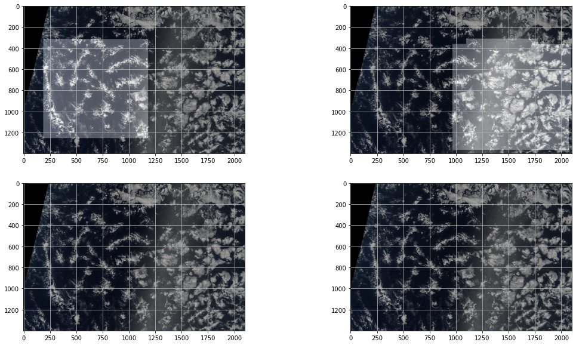

```python
from utils.dataset_helper import viz_image_mask_arrays
viz_image_mask_arrays(data_ori[0], data_ori[1])
```

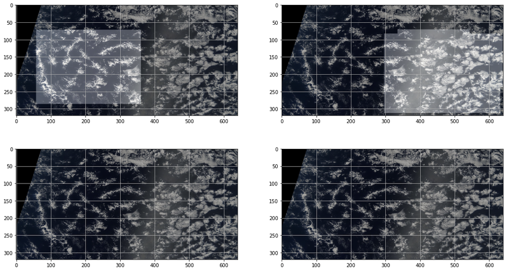

```python
viz_image_mask_arrays(data_pp[0], data_pp[1])
```

Here since we only applied a `resize` operation on the original image, we don't observe any change except the size (changed into 320 x 640). We can verify that the mask and the images are resized consistently.

```python
print("The size of the training dataset:", len(train_dataset))
print("The shape of input image data: ", data_pp[0].shape)
print("The shape of the input labels:", data_pp[1].shape)

print()
print("The max/min of the original image:", np.max(data_ori[0]), np.min(data_ori[0]))
print("The max/min of the preprocessed image:", np.max(data_pp[0]), np.min(data_pp[0]))
print("The mean/std of the preprocessed image:", np.mean(data_pp[0]), np.std(data_pp[0]))
```

```
The size of the training dataset: 37
The shape of input image data:  (3, 320, 640)
The shape of the input labels: (4, 320, 640)

The max/min of the original image: 255 0
The max/min of the preprocessed image: 1.0 0.0
The mean/std of the preprocessed image: 0.31877252 0.23482749
```

```python
#####################################
# UNET model using smp:
# Reference: https://github.com/qubvel/segmentation_models.pytorch#models
#####################################

# TODO: We put the activation in the loss function, so no need to repeat it here.
ACTIVATION = None
# ACTIVATION = 'sigmoid'
model = smp.Unet(
    encoder_name=ENCODER,
    encoder_weights=ENCODER_WEIGHTS,
    classes=4,
    activation=ACTIVATION,
)
```

## b. Loss Function

```python
from loss.dice_loss import BCEDiceLoss, DiceLoss, dice_no_threshold
criterion = BCEDiceLoss(activation='sigmoid')
```

# 3. Model Training

```python
#####################################
# Optimizer settings:
#####################################
from torch.optim.lr_scheduler import StepLR, ReduceLROnPlateau, CosineAnnealingLR

optimizer = torch.optim.Adam([
    {'params': model.decoder.parameters(), 'lr': 1e-2},
    {'params': model.encoder.parameters(), 'lr': 1e-3},
])
# Other values of learning rates which have been tested:
# (1e-3, 1e-4), (5e-3, 5e-4), (5e-2, 1e-2)

# opt_level = 'O1'
# model.cuda()
# model, optimizer = amp.initialize(model, optimizer, opt_level=opt_level)

# Using scheduler to apply learning reduce on Plateau:
scheduler = ReduceLROnPlateau(optimizer, factor=0.15, patience=2)
```

```python
from tqdm.auto import tqdm as tq
```

```python
# for i, p in enumerate(model.encoder.parameters()):
#   print(p.data.max(), p.data.min())

print("BEFORE training:")
params = list(model.encoder.parameters())
print("#parameter groups:", len(params))
print("The max/min of the params[0]:", params[0].data.max(), params[0].data.min())
print("The mean/std of the params[0]:", params[0].data.mean(), params[0].data.std())
print(params[0].grad is None)
```

```
BEFORE training:
#parameter groups: 60
The max/min of the params[0]: tensor(1.0165) tensor(-0.8434)
The mean/std of the params[0]: tensor(2.9420e-05) tensor(0.1297)
True
```

```python
torch.cuda.empty_cache()
```

```python
from models.runner import Runner

from datetime import datetime

rst_path = "/content/drive/My Drive/kaggle_cloud/run_20200617"

cld_runner = Runner(model, criterion)
train_rst = cld_runner.train(train_loader, valid_loader,
                optimizer, scheduler,
                valid_score_fn = dice_no_threshold,
                n_epochs = 50, train_on_gpu=True, verbose=True, rst_path = rst_path)
train_loss_list, valid_loss_list, dice_score_list = train_rst[0], train_rst[1], train_rst[2]
```

```python
params = list(model.encoder.parameters())
print("AFTER training:")
print("")
print("#parameter groups:", len(params))
print("The max/min of the params[0]:", params[0].data.max(), params[0].data.min())
print("The mean/std of the params[0]:", params[0].data.mean(), params[0].data.std())
print(params[0].grad is None)
```

```
AFTER training:

#parameter groups: 60
The max/min of the params[0]: tensor(1.0188, device='cuda:0') tensor(-0.8490, device='cuda:0')
The mean/std of the params[0]: tensor(-0.0002, device='cuda:0') tensor(0.1299, device='cuda:0')
False
```

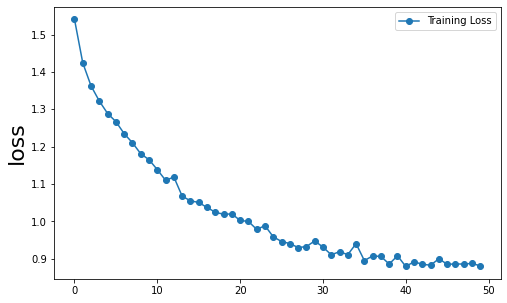

```python
import matplotlib.pyplot as plt

plt.figure(figsize=(8,5))
plt.plot(train_loss_list,  marker='o', label="Training Loss")
plt.ylabel('loss', fontsize=22)
plt.legend()
plt.show()
```

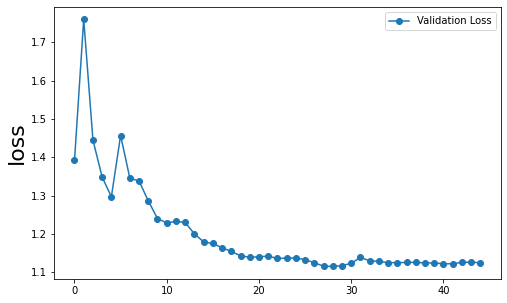

```python
plt.figure(figsize=(8, 5))

plt.plot(valid_loss_list[5:],  marker='o', label="Validation Loss")
plt.ylabel('loss', fontsize=22)
plt.legend()
plt.show()
```

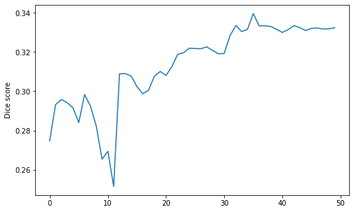

```python
plt.figure(figsize=(8,5))
plt.plot(dice_score_list)
plt.ylabel('Dice score')
plt.show()
```

**Summary:**

In this simple experiment, we have achieved the following:

- We have built up a learning pipeline to preprocess the image data, define a segmentation model using a high-level library, and train the model with a small dataset to verify the set-up.
- With a small training dataset and an proper optimimzer (learning rates), we can reduce the training error effectively, although there is still room to improve regarding the loss.